# MATH 4753 Project 2

Steven Tucker

26 April, 2019

Abstract

This project is all about applications of SLR to real data using R

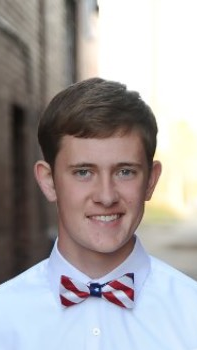

Steven Tucker

# 1 My Video

```r
#<video width="320" height="240" controls>
#  <source src="usingvideoinrmd.mp4" type="video/mp4">
#Your browser does not support the video tag.
#</video>
```

# 2 Abstract

This report is going to analyze how our perception of temperature based on humidity. To do this we will look into the relationship between three weather factors- Temperature, Apparent Temperature, and Humidity Level. This is an important analysis to look into because as our earth is quickly heating up due to pollution we need to know how these factors really do influence our perception of the temperature and how we can be best prepared to deal with it. The findings could apply to several areas of daily life for many people, especially those who spend long hours outdoors.

# 3 Introduction

This data set was gathered over the course of 10 years in Szeged, Hungary to measure any relationships between different factors in weather. Living in Oklahoma and being someone who sweats incredibly easy I want to see if I can find a relationship between apparent temperature and humidity. I have always heard that humidity makes it worse so I want to know if this is true.

The data was collected here:

[interactive chart not shown]

```r
library(dplyr)
library(lubridate)
```

```r
weather3.df=read.csv("weatherHistory.csv")

weather3.df$FormattedDate <- as.Date(weather3.df$FormattedDate)

weather3.df$Month <- months(weather3.df$FormattedDate)
weather3.df$Year <- format(weather3.df$FormattedDate, format="5y")
aggregate( Humidity ~ Month + Year , weather3.df , mean )
```

| Month | Year | Humidity |
| --- | --- | --- |
| April | 5y | 0.6411326 |
| August | 5y | 0.6355422 |
| December | 5y | 0.8703898 |
| February | 5y | 0.8134003 |
| January | 5y | 0.8507234 |
| July | 5y | 0.6396565 |
| June | 5y | 0.6864697 |
| March | 5y | 0.7029659 |
| May | 5y | 0.6913245 |
| November | 5y | 0.8278283 |

[output cut: 2 more lines]

## 3.1 What are the variables?

```r
weather=read.csv("weatherHistory.csv")
weather.df=read.csv("weatherHistory.csv")

colnames(weather) <- make.names(colnames(weather))
colnames(weather)
```

```
##  [1] "FormattedDate"          "Summary"
##  [3] "Precip.Type"            "TemperatureC"
##  [5] "ApparentTemperatureC"   "Humidity"
##  [7] "WindSpeedkmh"           "Wind.Bearing..degrees."
##  [9] "Visibility..km."        "Loud.Cover"
## [11] "Pressure..millibars."   "Daily.Summary"
```

```r
set.seed(55); weather = weather[sample(nrow(weather), 50),]
set.seed(55); weather.df = weather.df[sample(nrow(weather), 50),]

head(weather)
```

|  | FormattedDate | Summary | Precip.Type | TemperatureC | ApparentTemperatureC | Humidity | WindSpeedkmh | Wind.Bearing..degrees. | Visibility..km. | Loud.Cover | Pressure..millibars. | Daily.Summary |
| --- | --- | --- | --- | --- | --- | --- | --- | --- | --- | --- | --- | --- |
| 52839 | 2012-01-10 14:00:00.000 +0100 | Mostly Cloudy | rain | 2.222222 | 1.022222 | 0.92 | 4.8300 | 220 | 11.2700 | 0 | 1024.10 | Mostly cloudy throughout the day. |
| 21042 | 2008-05-26 18:00:00.000 +0200 | Overcast | rain | 22.888889 | 22.888889 | 0.65 | 7.5670 | 94 | 11.2056 | 0 | 1016.06 | Mostly cloudy throughout the day. |
| 3373 | 2006-05-21 13:00:00.000 +0200 | Mostly Cloudy | rain | 21.100000 | 21.100000 | 0.57 | 9.0160 | 37 | 11.2056 | 0 | 1012.39 | Mostly cloudy throughout the day. |
| 76345 | 2014-09-16 04:00:00.000 +0200 | Overcast | rain | 14.305556 | 14.305556 | 1.00 | 3.2200 | 70 | 15.4077 | 0 | 1017.83 | Mostly cloudy throughout the day. |
| 54035 | 2012-02-29 10:00:00.000 +0100 | Mostly Cloudy | rain | 6.372222 | 3.344444 | 0.86 | 15.7941 | 38 | 11.0768 | 0 | 1013.04 | Partly cloudy starting overnight continuing until night and breezy in the morning. |
| 7159 | 2006-10-26 07:00:00.000 +0200 | Partly Cloudy | rain | 7.894444 | 7.894444 | 0.89 | 0.4025 | 83 | 9.9015 | 0 | 1022.28 | Mostly cloudy starting overnight continuing until night. |

It is clear from the head of the data set that we are dealing with both qualitative and quantitative variables. Many of the variables are not what I want to look at for now and will overcomplicate the data set so I will get rid of those variables for this assignment.

```r
weather2=weather[,c(4,5,6)]
head(weather2)
```

|  | TemperatureC | ApparentTemperatureC | Humidity |
| --- | --- | --- | --- |
| 52839 | 2.222222 | 1.022222 | 0.92 |
| 21042 | 22.888889 | 22.888889 | 0.65 |
| 3373 | 21.100000 | 21.100000 | 0.57 |
| 76345 | 14.305556 | 14.305556 | 1.00 |
| 54035 | 6.372222 | 3.344444 | 0.86 |
| 7159 | 7.894444 | 7.894444 | 0.89 |

This will significantly narrow down the data set to what we actually want to look at. These are all continuous quantitative variables which makes defining a relationship easier and more clear to do, assuming there is one.

### 3.1.1 Plot data

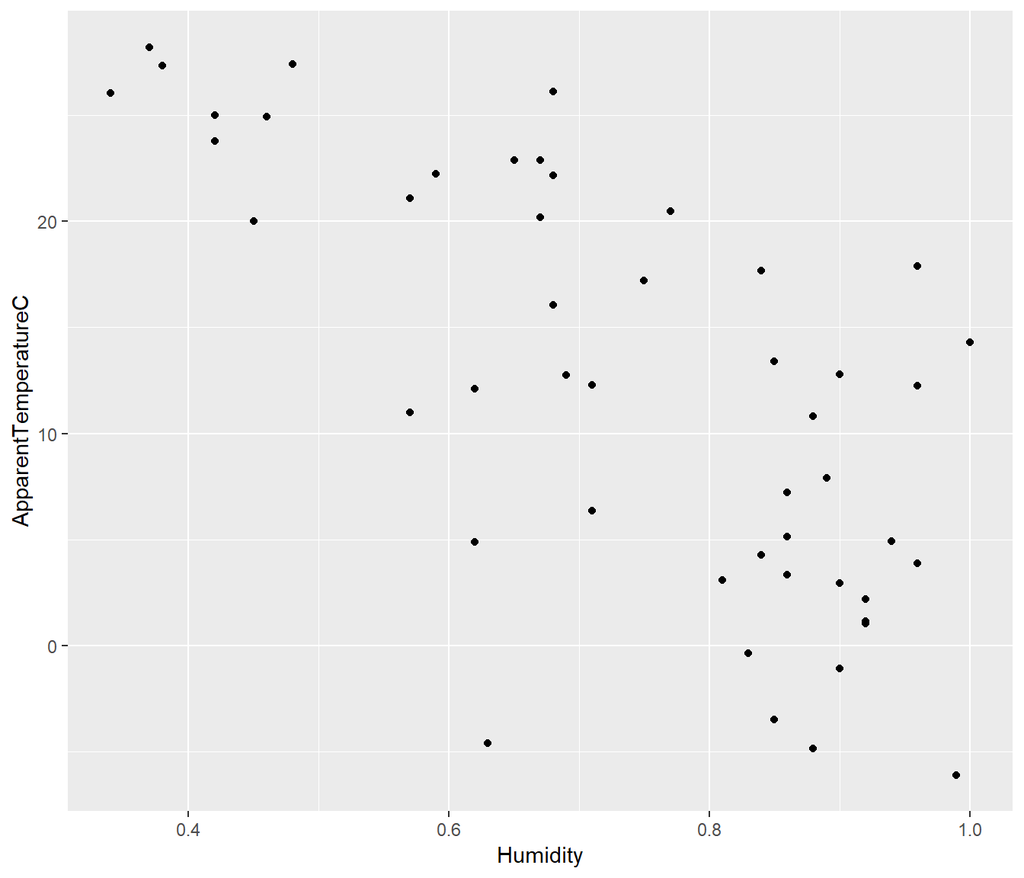

```r
library(ggplot2)
g = ggplot(weather2, aes(x = Humidity, y = ApparentTemperatureC)) + geom_point()
g
```

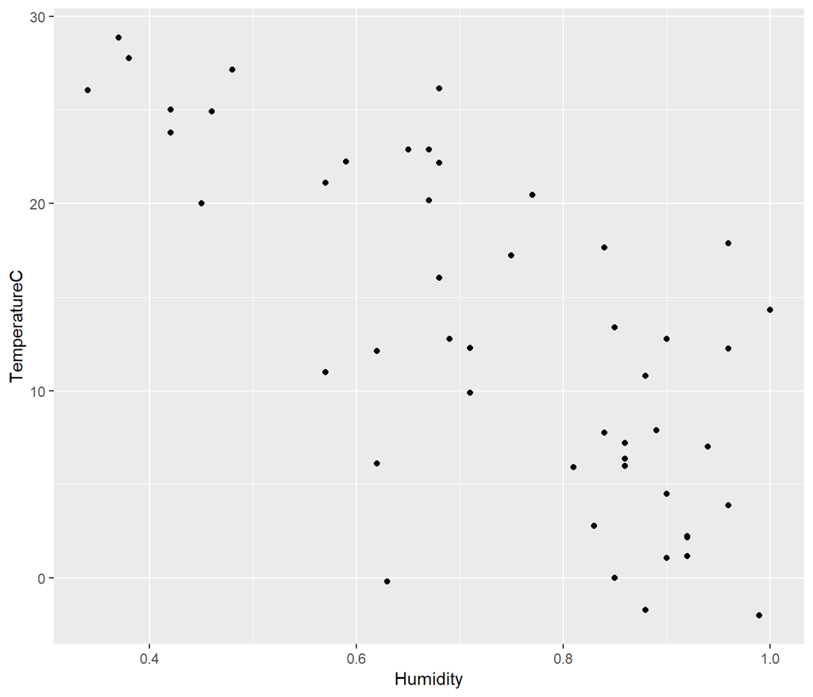

```r
g = ggplot(weather2, aes(x = Humidity, y = TemperatureC)) + geom_point()
g
```

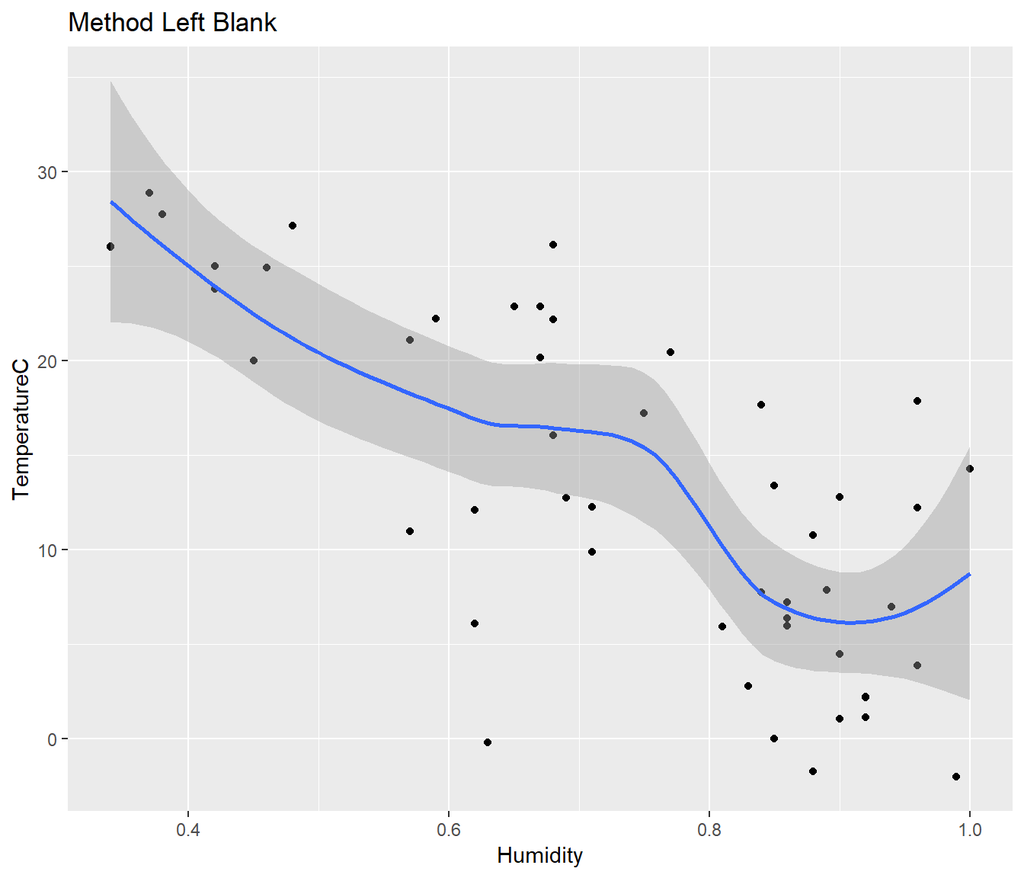

```r
ggplot(weather2, aes(x = Humidity, y = TemperatureC)) +
    geom_point() +
    geom_smooth() +
    labs(title = "Method Left Blank")
```

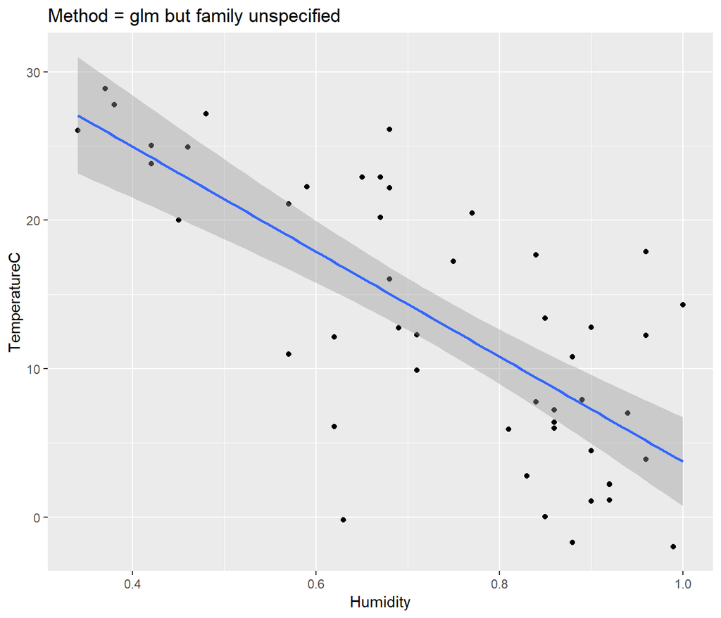

```r
ggplot(weather, aes(x = Humidity, y = TemperatureC)) +
    geom_point() +
    geom_smooth(method = "glm") +
    labs(title = "Method = glm but family unspecified")
```

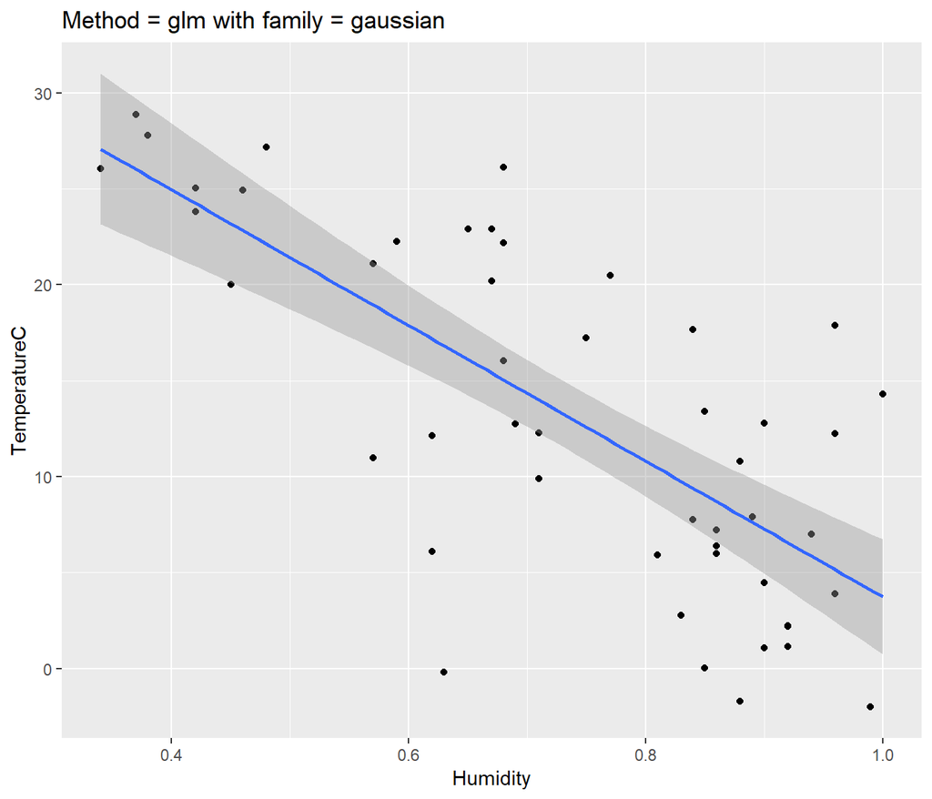

```r
ggplot(weather, aes(x = Humidity, y = TemperatureC)) +
    geom_point() +
    geom_smooth(method = "glm", method.args = list(family = "gaussian")) +
    labs(title = "Method = glm with family = gaussian")
```

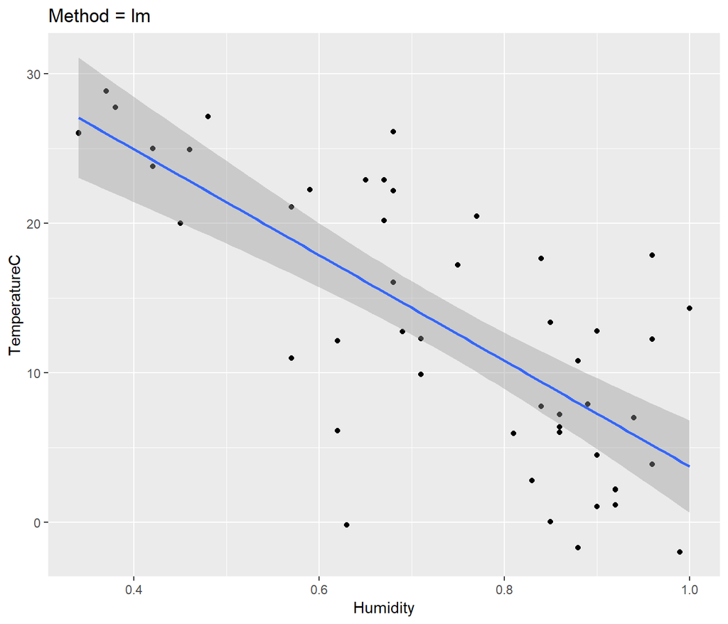

```r
ggplot(weather, aes(x = Humidity, y = TemperatureC)) +
    geom_point() +
    geom_smooth(method = "lm") +
    labs(title = "Method = lm")
```

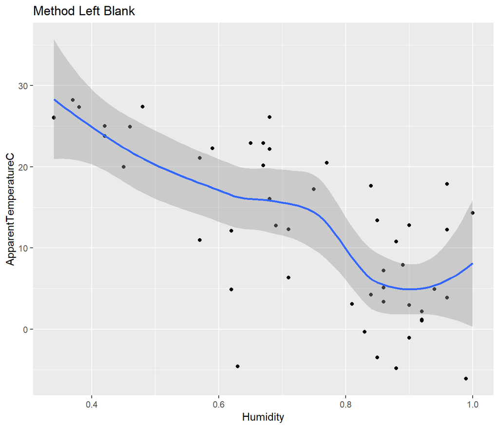

```r
ggplot(weather2, aes(x = Humidity, y = ApparentTemperatureC)) +
    geom_point() +
    geom_smooth() +
    labs(title = "Method Left Blank")
```

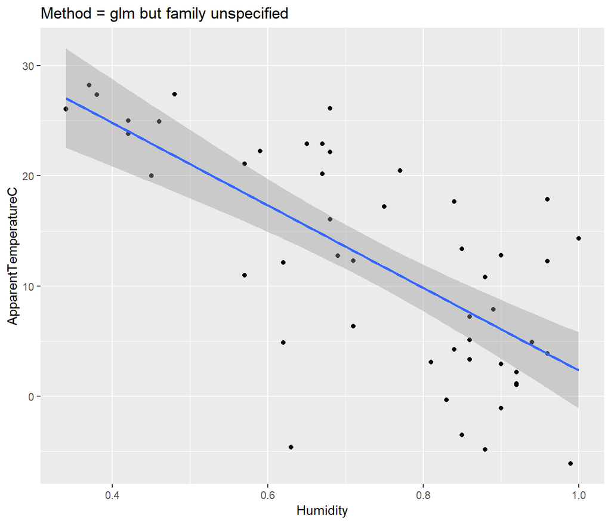

```r
ggplot(weather, aes(x = Humidity, y = ApparentTemperatureC)) +
    geom_point() +
    geom_smooth(method = "glm") +
    labs(title = "Method = glm but family unspecified")
```

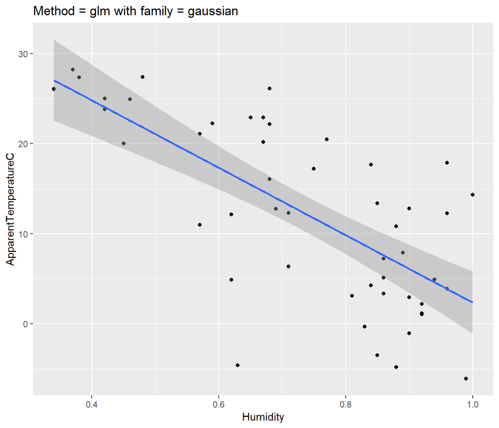

```r
ggplot(weather, aes(x = Humidity, y = ApparentTemperatureC)) +
    geom_point() +
    geom_smooth(method = "glm", method.args = list(family = "gaussian")) +
    labs(title = "Method = glm with family = gaussian")
```

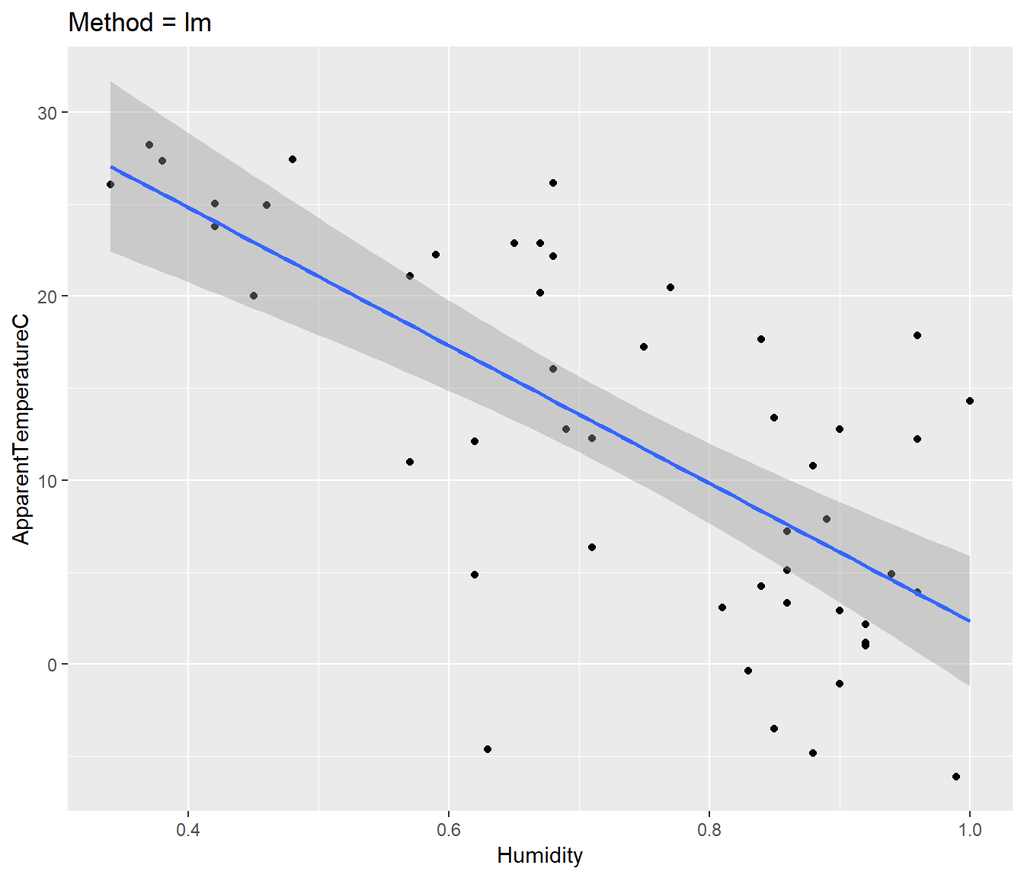

```r
ggplot(weather, aes(x = Humidity, y = ApparentTemperatureC)) +
    geom_point() +
    geom_smooth(method = "lm") +
    labs(title = "Method = lm")
```

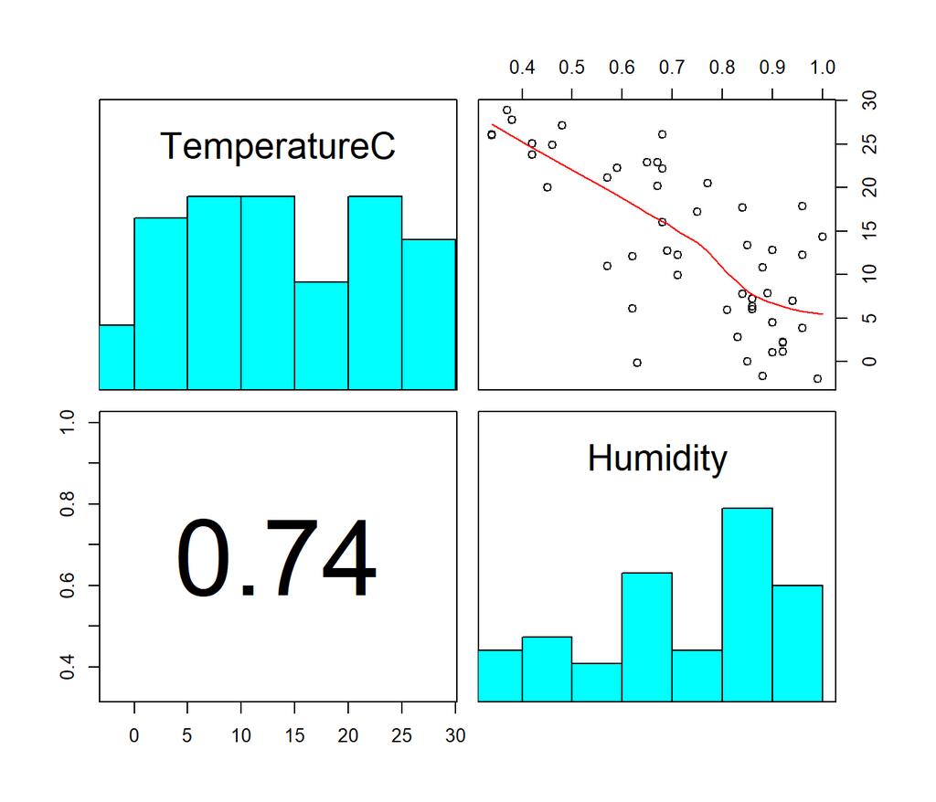

```r
controlExp = weather[,c(4,6)]
appExp = weather[,c(5,6)]

library (s20x)
pairs20x(controlExp)
```

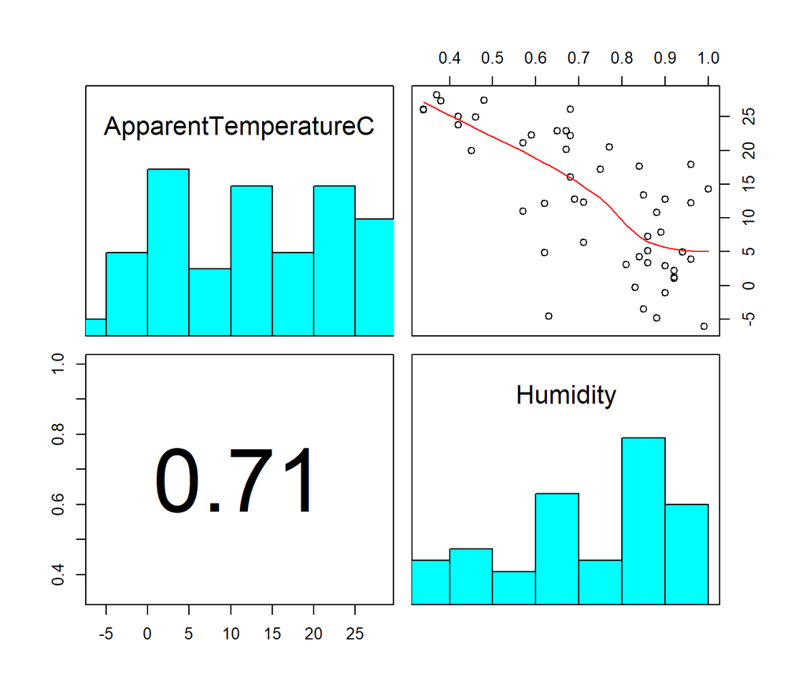

```r
pairs20x(appExp)
```

These graphs help us to paint a picture for the type of relationship the two factors have with eachother and it is already surprising to me. Going into the assignment I assumed an increase in humidity would lead to an increase in Apparent temperature.

```r
table(is.na(weather2$ApparentTemperatureC))
```

```
##
## FALSE
##    50
```

```r
table(is.na(weather2$TemperatureC))
```

```
##
## FALSE
##    50
```

```r
table(is.na(weather2$Humidity))
```

```
##
## FALSE
##    50
```

It appears there is no missing data so it looks like we are good to ROCK AND ROLL on this now.

## 3.2 How were the data collected?

The data was collected by measuring a number of weather details each hour of each day for a decade.

## 3.3 What is the story behind the data? Why was it gathered?

I searched extensively for background details on this file and was unable to find a specific reason or background as to why the data was taken in the first place but when considering how important weather is in our day-to-day lives it is not far fetched to assume the data was taken for the purpose of better understanding the world we live in. The Wikipedia page for Szeged noted the high number of hours for sunlight in the city and mentioned it is often called the “City of Sunshine.” This may seem like an odd statistic to measure but WeatherSpark.com did also point out that this weather attracts three significant things for the city. The first is tourism. WeatherSpark went as far as calculating the best time to visit by considering average monthly temperature, cloud coverage and precipitation. They found the best time would be late May to mid September. They were also able to calculate the most common period of time to go to the beaches and pools there would be early July to mid August. A graph of their findings is below-

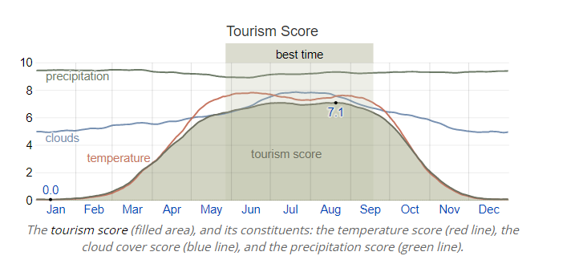

Tourism

According to the WeatherSpark article, significant areas of Szeged are dedicated to farming. This further highlights the importance of understanding the data and using it to societies advantage. For Szeged the growing season is considered to last 6 and a half months.

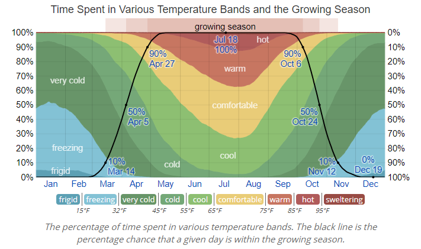

Farming

The third industry that benefits from the great weather and amounts of sunlight is the city’s Solar Energy production. This data could go to help energy production companies decide when and where to invest in placing equipment in the “City of Sunshine.”

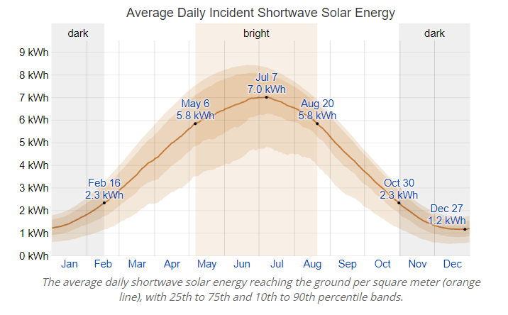

Solar Energy

## 3.4 What is your interest in the data?

My immediate interest with the data is in what factors influence our perception of how hot it is outside. I sweat significantly easier than most people so when I am checking the weather for the day I always need to keep in mind any distance I need to cover to get to class and if the weather will be sunny and hot then I will wear darker shirts to conceal any sweat. I also enjoy hiking in my free time and when you pack up to go several miles from a car it is important to keep in mind the days weather but something I am guilty of is neglecting to look at wind speed and humidity, so highlighting the importance of those factors is something I aim to do in these exercises. I am also currently interested in working as a first responder for some period of time after graduating so weather could easily impact day to day life in that field.

Aside from my interest in how the analysis of the data will affect my own future life I think the data collection in itself is interesting. The fact that someone was able to take data everyday on the hour for ten years without any missing values is incredible.

## 3.5 What problem do you wish to solve?/ Research Question

Many “problems” have been outlined and solved by WeatherSpark’s article on the data but what I want to look at is the effect Humidity has on our Apparent temperature, ie- does humidity make us feel hotter? To do this I will look at the Linear Regression Model for Humidity and Apparent Temperature as well as the Linear Regression Model for Humidity and Temperature. In these comparisons I will be using Temperature as our constant variable, Humidity as our independent variable and Apparent Temperature as our dependent variable. To measure if there is any difference in percieved temperature vs actual I will take the SLR models and compare their beta values. My expectation is that apparent temperature will be higher with higher humidity than actual temperature will be with lower humidity.

# 4 Theory needed to carry out SLR

Following the graphs above it is appears our Temperature Y-value decreases linearly (with a few outliers) as Humidity increases. The Simple Linear Regression model is described by the following-

$$y = \beta_0+\beta_1 x + \epsilon\\$$

For this experiment we will have two cases. The first will describe the controlled case and will use actual temperature as the dependent variable and Humidity as the independent variable as described below-

$$\textsf{Temperature (C) }= \beta_0 + \beta_1 (\textsf{Humidity}) + \epsilon\\$$
The second case will hold Apparent Temperature as the dependent variable and Humidity as the independant variable-

$$\textsf{Apparent Temperature (C) }= \beta_0+\beta_1(\textsf{Humidity}) + \epsilon \\$$

We cannot use a deterministic model because of the wide spread of results but we can use the above Simple Linear Regression Model because it is a type of probabalistic model which can more accurately portray this data set. The idea of a Simple Linear Regression model will lean on the assumption that the mean value of our dependent variable (or our Temperature vars) will make a straight line when graphed and if a point deviates it will be equal to epsilon.

At this point B_0 and B_1 are both unknown to us but we can assume that there will be some negative deviation and some positive deviation so it would be permissable to set the expected value of epsilon_i = 0, and we would have the following-

$$E(y)=E(\beta_0+\beta_1x_i+ \epsilon_i)\\
= \beta_0+\beta_i x_1$$
Knowing this, we also know that the we can represent the mean of our dependent Temperature for any x with E(Y|x). Furthermore, it will graph linearly by using y-intercept B_0 and a slope B_1.

Our next move is to fit an SLR to the data set. To accomplish this I will need to make estimations for the betas based on the sampling distributions of the estimators and those will depend on the epsilon value.  
List of assumptions- Epsilon = 0 The probablity distribution of epsilon is normal Errors are indepentant of one another V(Epsilon)= some constant for all valse of x

# 5 Estimating The Parameters

## 5.1 Method of Least Squares

```r
weatherCont=weather[,c(4,6)]
head(weatherCont)
```

|  | TemperatureC | Humidity |
| --- | --- | --- |
| 52839 | 2.222222 | 0.92 |
| 21042 | 22.888889 | 0.65 |
| 3373 | 21.100000 | 0.57 |
| 76345 | 14.305556 | 1.00 |
| 54035 | 6.372222 | 0.86 |
| 7159 | 7.894444 | 0.89 |

```r
weatherExp.lm=with(lm(Humidity~ApparentTemperatureC), data=weather2)
weatherCont.lm=with(lm(Humidity~TemperatureC), data=weatherCont)
summary(weatherExp.lm)
```

```
##
## Call:
## lm(formula = Humidity ~ ApparentTemperatureC)
##
## Residuals:
##      Min       1Q   Median       3Q      Max
## -0.33159 -0.09906  0.00301  0.08472  0.30429
##
## Coefficients:
##                       Estimate Std. Error t value Pr(>|t|)
## (Intercept)           0.898809   0.030892  29.095  < 2e-16 ***
## ApparentTemperatureC -0.013598   0.001929  -7.051 6.15e-09 ***
## ---
## Signif. codes:  0 '***' 0.001 '**' 0.01 '*' 0.05 '.' 0.1 ' ' 1
##
## Residual standard error: 0.1365 on 48 degrees of freedom
## Multiple R-squared:  0.5088, Adjusted R-squared:  0.4985
## F-statistic: 49.71 on 1 and 48 DF,  p-value: 6.151e-09
```

```r
summary(weatherCont.lm)
```

```
##
## Call:
## lm(formula = Humidity ~ TemperatureC)
##
## Residuals:
##       Min        1Q    Median        3Q       Max
## -0.309116 -0.085249  0.009443  0.083686  0.302088
##
## Coefficients:
##               Estimate Std. Error t value Pr(>|t|)
## (Intercept)   0.936262   0.032765  28.575  < 2e-16 ***
## TemperatureC -0.015570   0.002031  -7.666 7.06e-10 ***
## ---
## Signif. codes:  0 '***' 0.001 '**' 0.01 '*' 0.05 '.' 0.1 ' ' 1
##
## Residual standard error: 0.1306 on 48 degrees of freedom
## Multiple R-squared:  0.5504, Adjusted R-squared:  0.5411
## F-statistic: 58.77 on 1 and 48 DF,  p-value: 7.056e-10
```

For the actual Temperature Linear Model we have

## 5.2 CI for Parameter Estimates

```r
ciReg(weatherExp.lm, conf.level = 0.95, print.out = TRUE)
```

```
##                      95 % C.I.lower    95 % C.I.upper
## (Intercept)                 0.83670           0.96092
## ApparentTemperatureC       -0.01748          -0.00972
```

```r
ciReg(weatherCont.lm, conf.level = 0.95, print.out = TRUE)
```

```
##              95 % C.I.lower    95 % C.I.upper
## (Intercept)         0.87038           1.00214
## TemperatureC       -0.01965          -0.01149
```

# 6 Verify Assumptions

The next step in this process is to show whether or not the line of best fit for this data is a straight one but in order to do that I need to veryify the assumtions I had previously mentioned. I have listed them again below- List of assumptions- Epsilon = 0 The probablity distribution of epsilon is normal Errors are indepentant of one another V(Epsilon)= some constant for all valse of x

```r
head(weather2)
```

|  | TemperatureC | ApparentTemperatureC | Humidity |
| --- | --- | --- | --- |
| 52839 | 2.222222 | 1.022222 | 0.92 |
| 21042 | 22.888889 | 22.888889 | 0.65 |
| 3373 | 21.100000 | 21.100000 | 0.57 |
| 76345 | 14.305556 | 14.305556 | 1.00 |
| 54035 | 6.372222 | 3.344444 | 0.86 |
| 7159 | 7.894444 | 7.894444 | 0.89 |

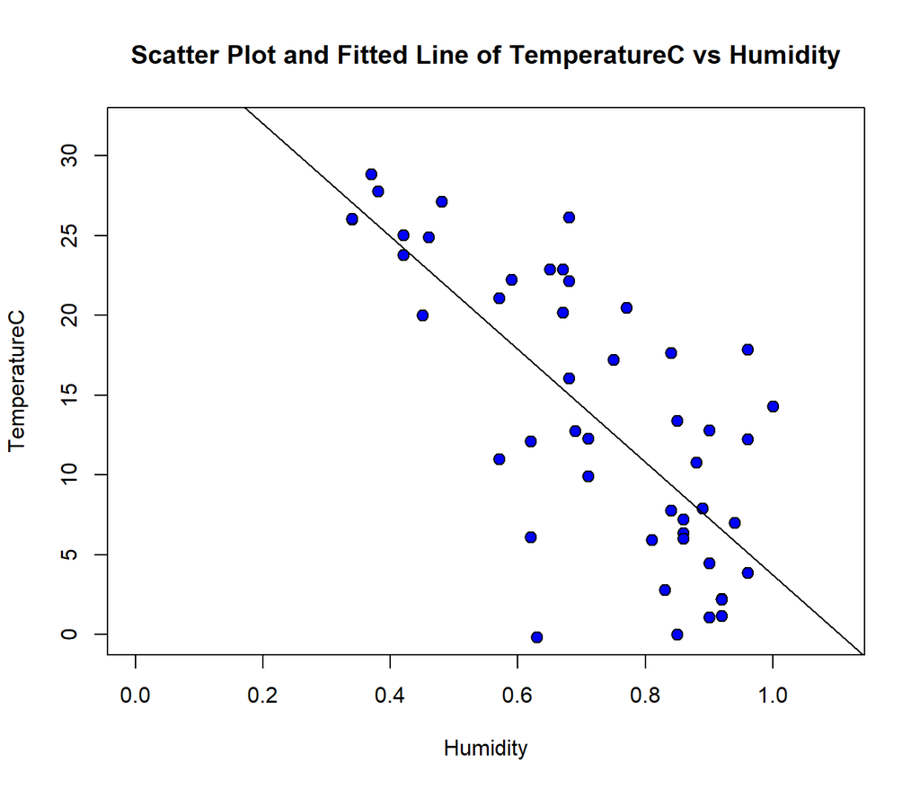

```r
plot(TemperatureC~Humidity,bg="Blue",pch=21,cex=1.2,
     ylim=c(0,1.1*max(TemperatureC)),xlim=c(0,1.1*max(Humidity)),
     main="Scatter Plot and Fitted Line of TemperatureC vs Humidity", data=weather2)
ht.lm=with(weather2, lm(TemperatureC~Humidity))
abline(ht.lm)
```

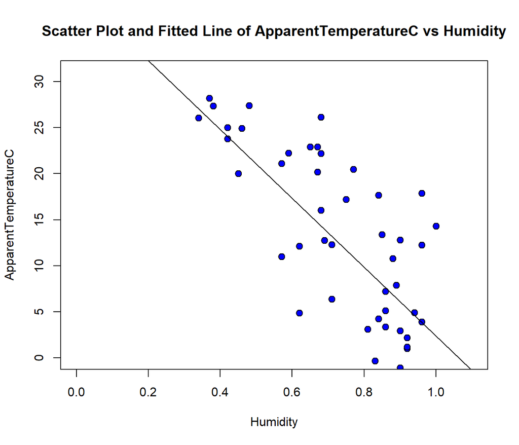

```r
plot(ApparentTemperatureC~Humidity,bg="Blue",pch=21,cex=1.2,
     ylim=c(0,1.1*max(ApparentTemperatureC)),xlim=c(0,1.1*max(Humidity)),
     main="Scatter Plot and Fitted Line of ApparentTemperatureC vs Humidity", data=weather2)
ht.lm=with(weather2, lm(ApparentTemperatureC~Humidity))
abline(ht.lm)
```

## 6.1 Plot the Residuals

We need to find the RSS or residual sum of squares and one way to do that is to plot the residuals themselves. This will show the deviations of the points about the fitted line.

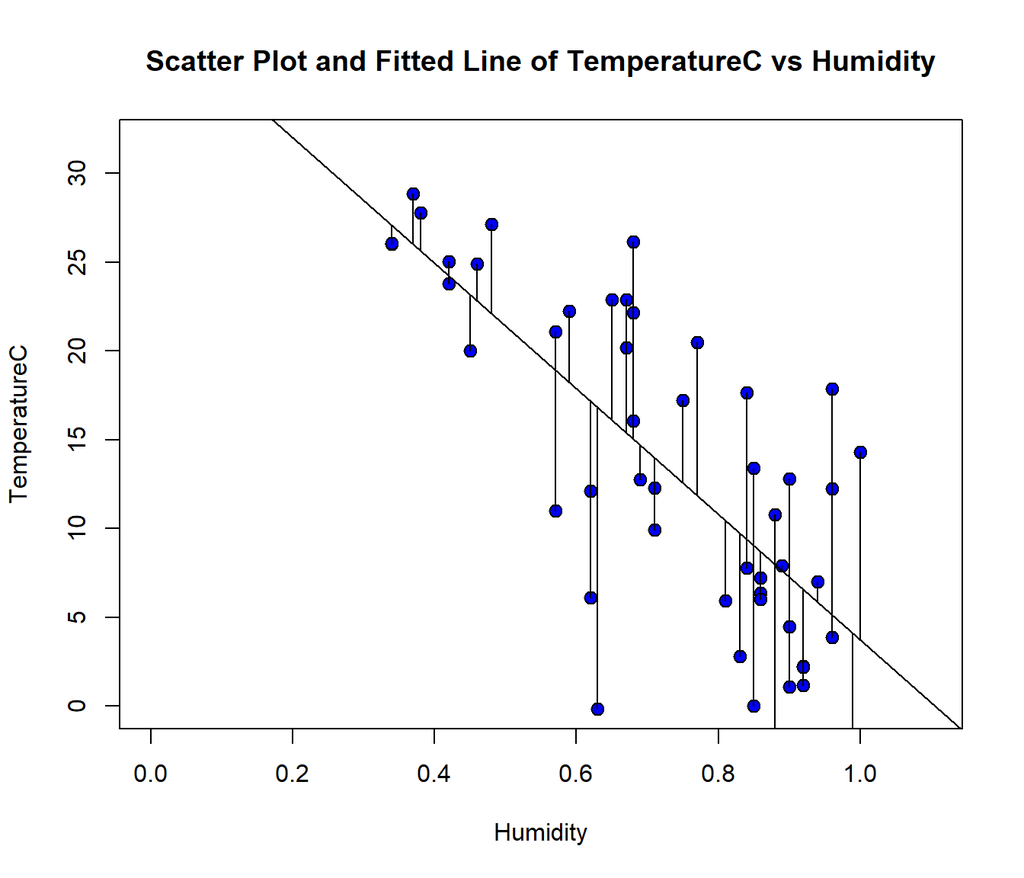

```r
plot(TemperatureC~Humidity,bg="Blue",pch=21,cex=1.2,
     ylim=c(0,1.1*max(TemperatureC)),xlim=c(0,1.1*max(Humidity)),
     main="Scatter Plot and Fitted Line of TemperatureC vs Humidity", data=weather2)
ht.lm=with(weather2, lm(TemperatureC~Humidity))
abline(ht.lm)
yhat=with(weather2,predict(ht.lm,data.frame(Humidity)))
with(weather,{segments(Humidity,TemperatureC,Humidity,yhat)})
abline(ht.lm)
```

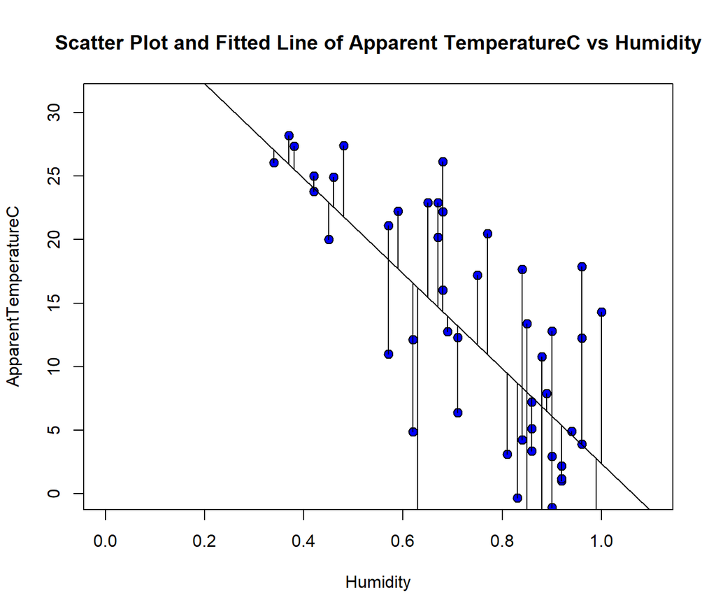

```r
plot(ApparentTemperatureC~Humidity,bg="Blue",pch=21,cex=1.2,
     ylim=c(0,1.1*max(ApparentTemperatureC)),xlim=c(0,1.1*max(Humidity)),
     main="Scatter Plot and Fitted Line of Apparent TemperatureC vs Humidity", data=weather2)
ht.lm=with(weather2, lm(ApparentTemperatureC~Humidity))
abline(ht.lm)
yhat=with(weather2,predict(ht.lm,data.frame(Humidity)))
with(weather,{segments(Humidity,ApparentTemperatureC,Humidity,yhat)})
abline(ht.lm)
```

## 6.2 Plot of Means

In order to visualize the difference between the means of the data sets I have graphed them below. With the fitted line deviations this will help us in getting the MSS or model sum of squares which will be used with RSS later.

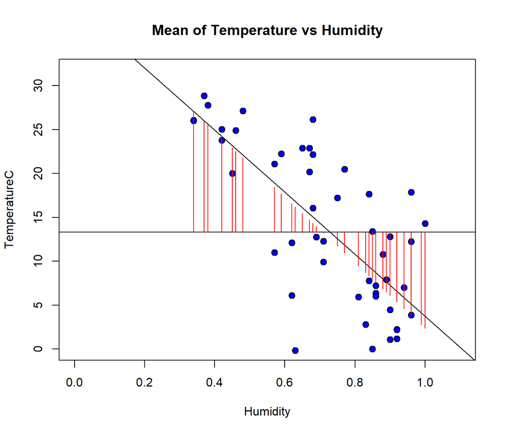

```r
plot(TemperatureC~Humidity,bg="Blue",pch=21,cex=1.2,
             ylim=c(0,1.1*max(TemperatureC)),xlim=c(0,1.1*max(Humidity)),
             main="Mean of Temperature vs Humidity", data=weatherCont)
ht.lm=with(weatherCont, lm(TemperatureC~Humidity))
abline(ht.lm)
with(weatherCont, abline(h=mean(TemperatureC)))
abline(ht.lm)
with(weatherCont, segments(Humidity,mean(TemperatureC),Humidity,yhat,col="Red"))
```

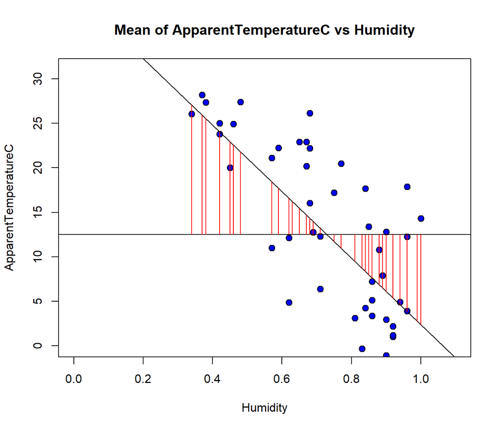

```r
plot(ApparentTemperatureC~Humidity,bg="Blue",pch=21,cex=1.2,
             ylim=c(0,1.1*max(ApparentTemperatureC)),xlim=c(0,1.1*max(Humidity)),
             main="Mean of ApparentTemperatureC vs Humidity", data=weather2)
ht.lm=with(weather2, lm(ApparentTemperatureC~Humidity))
abline(ht.lm)
with(weather2, abline(h=mean(ApparentTemperatureC)))
abline(ht.lm)
with(weather2, segments(Humidity,mean(ApparentTemperatureC),Humidity,yhat,col="Red"))
```

## 6.3 Plot Means with Total Deviation Line Segments

Plot the means of Temperature versus the humidity with the total deviation line segments to show yhat = ybar and get TSS or total sum of squares.

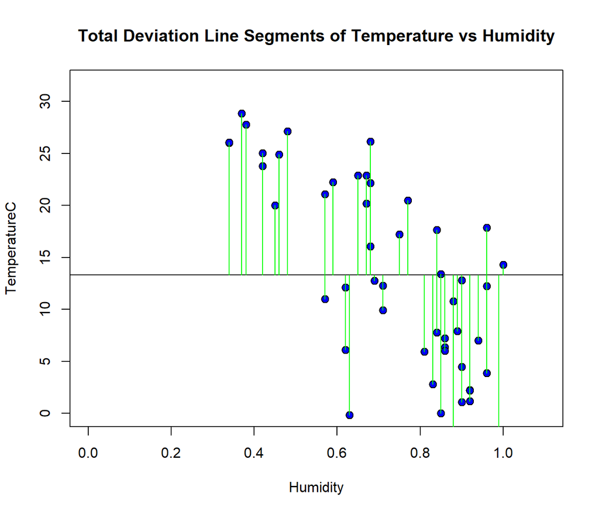

```r
plot(TemperatureC~Humidity,bg="Blue",pch=21,cex=1.2,
              ylim=c(0,1.1*max(TemperatureC)),xlim=c(0,1.1*max(Humidity)),
              main="Total Deviation Line Segments of Temperature vs Humidity", data=weather2)
with(weather2,abline(h=mean(TemperatureC)))
with(weather2, segments(Humidity,TemperatureC,Humidity,mean(TemperatureC),col="Green"))
```

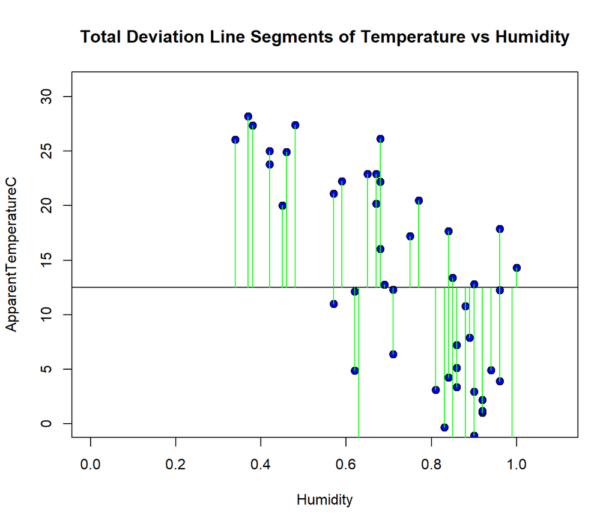

```r
plot(ApparentTemperatureC~Humidity,bg="Blue",pch=21,cex=1.2,
              ylim=c(0,1.1*max(ApparentTemperatureC)),xlim=c(0,1.1*max(Humidity)),
              main="Total Deviation Line Segments of Temperature vs Humidity", data=weather2)
with(weather2,abline(h=mean(ApparentTemperatureC)))
with(weather2, segments(Humidity,ApparentTemperatureC,Humidity,mean(ApparentTemperatureC),col="Green"))
```